# YeastData

William M. Woodman

2025-06-26

This RMarkdown file lists the scripts that need to be run in order to reproduce the experimental data results from the paper `Brownian motion, bridging and Bayesian inference in phylogenetic tree space’. This includes

- Running the main inference on the source tree and dispersion parameters (Java).
- Producing the diagnostic and summary plots, and computing modal edge lengths in the modal topology (R).
- Building the modal tree and estimating a Fréchet mean (Java).
- Running the inference with source parameter fixed at the Fréchet mean to estimate modal value of dispersion to use in FM marginal likelihood estimation.
- Estimating marginal likelihoods using three different methods and three different trees (Java).
- Forward simulating from the model with the modal parameters from the inference to perform model checking (Java).
- Producing plots for the model checking (R).

The following shell scripts will be run and this RMarkdown shows the order to run them in order to reproduce the output of the paper.

- The data is included in the github repository in the YeastData folder. To save space in storing the MCMC output we converted the taxa names to integers using the following conversion:

[output not shown]

The main inference procedure and calculation of the Fréchet mean is run using the script:

- run_yeast.sh

Plots from the output of the MCMC for the yeast data.:

```
## [1] "x0 acceptance rate  0.2480947"
```

```
## [1] "t0 acceptance rate  0.1096282"
```

```
## [1] "average bridge acceptance rate  0.632241271698113"
```

```
##   Parameter              Rate
## 1        x0         0.2480947
## 2        t0         0.1096282
## 3   bridges 0.632241271698113
```

```
## [1] "traceplot of the dispersion parameter:"
```

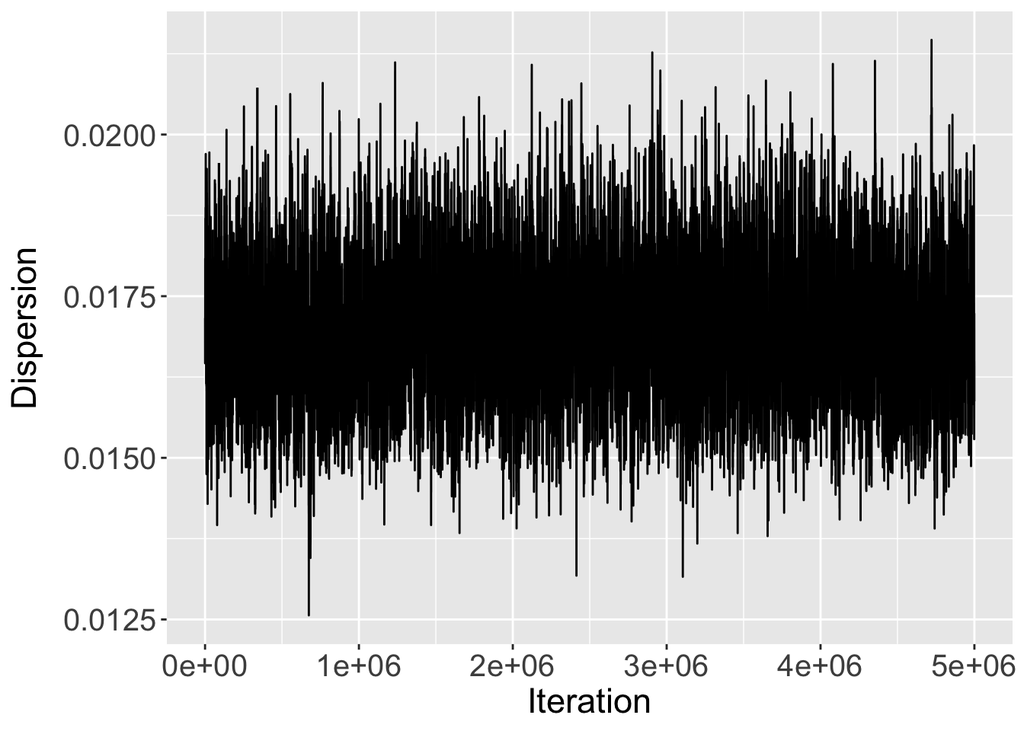

```
## [1] "Trace plot of the log likelihood:"
```

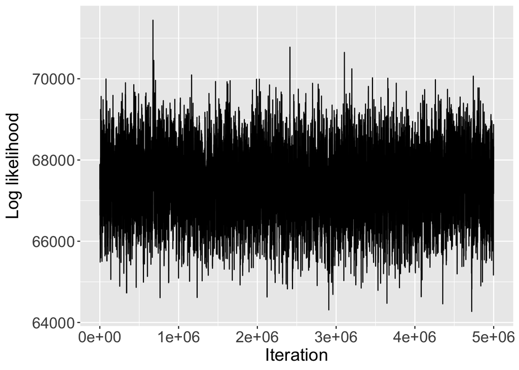

```
## [1] "kernel density estimate from the sampled values of dispersion:"
```

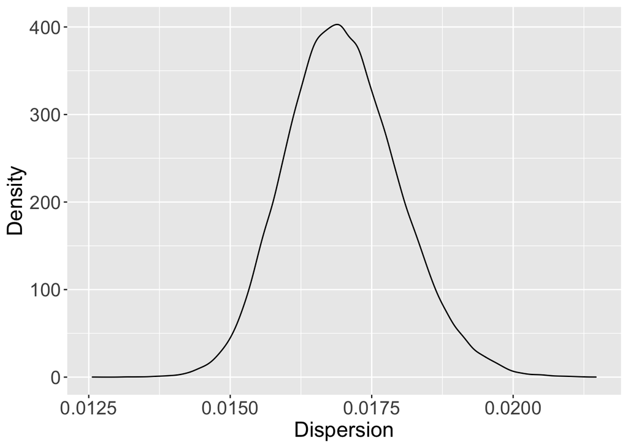

```
## [1] "t0 mode is (use this for marginal likelihoods): 0.0168927917406883"
```

```
## [1] "Plot the proportion of the top topologies in the posterior:"
```

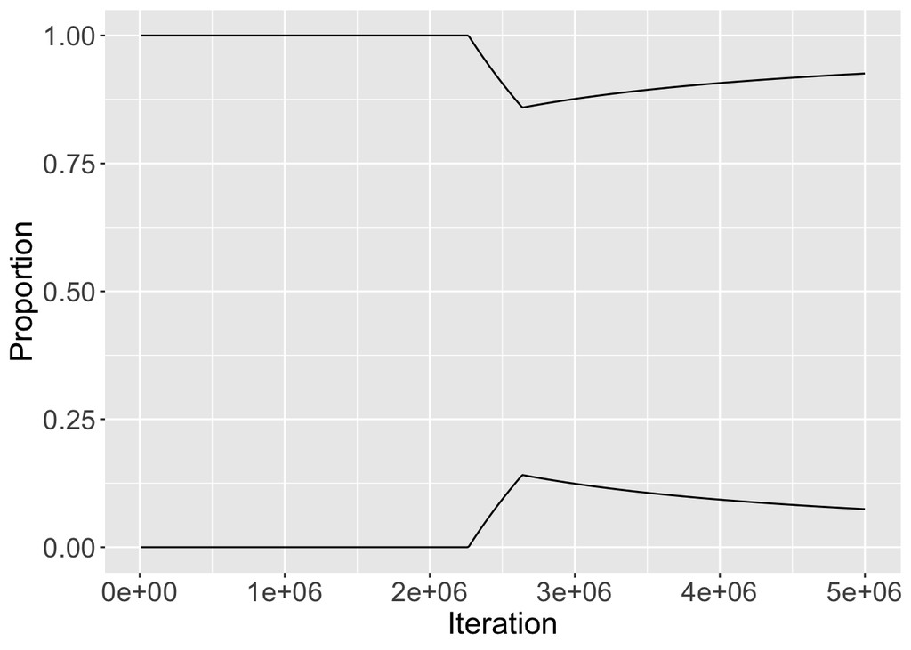

```
## [1] "Plot of kernel density estimates of the edge lengths in the posterior:"
```

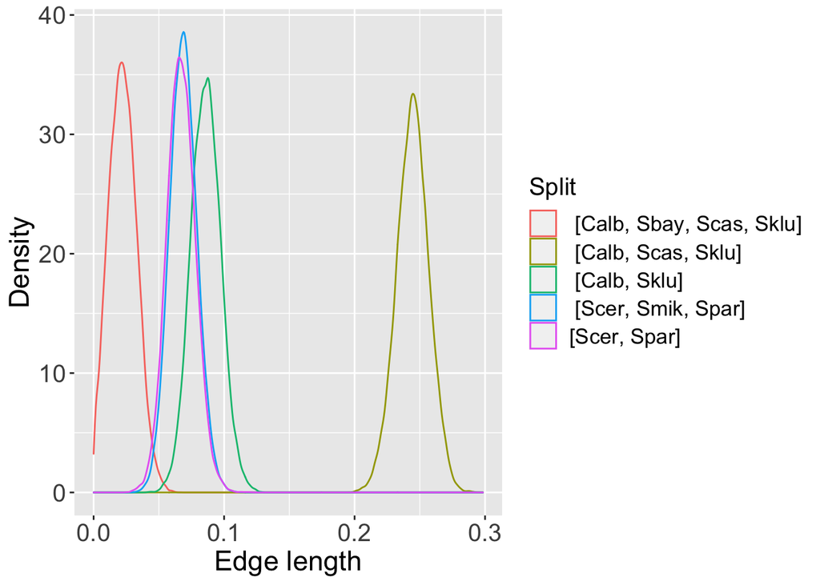

```
##                        Topology Proportion
## 1: (2,(3,(1,5)),(6,(7,(4,8))));      92.6%
## 2: ((2,6),(3,(1,5)),(7,(4,8)));       7.4%
```

We find a mode tree by taking the mode of the KDEs for each edge length in the modal topology in the posterior sample. After the below has been run, the mode tree is built using the script

- run_yeast_summary_trees.sh

which also calculates the total internal edge lengths on the Fréchet mean and source tree.

We now compare the distances from the mode tree to i) the data and ii) particles forward simulated under the fitted model. Particles are forward simulated under the fitted model using the script * run_yeast_posterior_checks.sh

```
## [1] "Plot of the BHV distances between the modal tree and the data set (bars) and the simulated particles (line)"
```

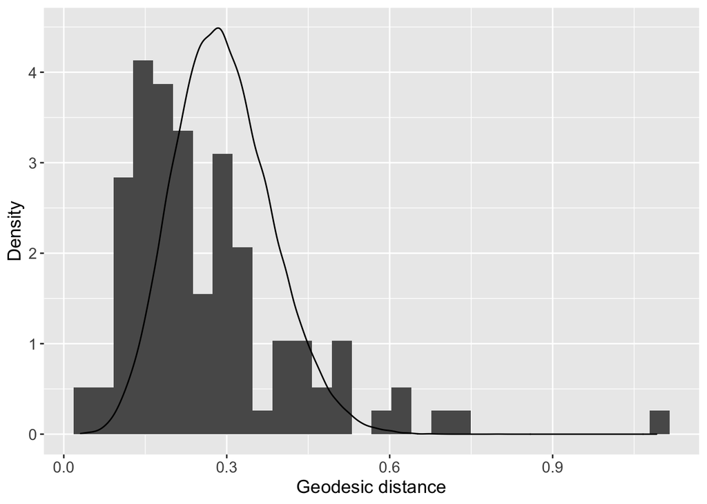

Now we get the value of t0 to use in the marginal likelihood calculations for the Fréchet mean. This is done by running the inference fixed at the Fréchet mean using the script:

- run_yeast_FM_MCMC.sh

```
## [1] "t0 mode is (use this for marginal liklelihoods): 0.0166780745901759"
```

Now it remains to run the marginal likelihood estimators with the following files:

- Fréchet mean, stepping stone - run_yeast_StepStone_FM.sh
- Fréchet mean, Chib and tunnel - run_yeast_Chib_FM.sh
- Modal tree, stepping stone - run_yeast_StepStone_Modal.sh
- Modal tree, Chib and tunnel - run_yeast_Chib_modal.sh
- Star tree